# Módulo 03 - Propriedades de uma rede

Sillas Teixeira Gonzaga

27 de março de 2018

## Redes direcionadas e não direcionadas

As arestas ou ligações de uma rede podem ser direcionadas, na qual o vetor de direção importa, ou não direcionadas. Uma rede de seguidores de Twitter, por exemplo, é direcionada, visto que é possível o usuário A seguir o usuário B sem que isso seja recíproco. Já uma rede de amigos no Facebook, por outro lado, é não direcionada, visto que, pelas regras do site, se o usuário A é amigo do usuário B então B também é amigo de A.

Exemplos de ligações de redes direcionadas:  
* E-mails e telefonemas  
* Citações acadêmicas  
* Internet

Exemplos de ligações não direcionadas:  
* Relacionamentos, como amizade e namoro  
* Redes de transmissão elétrica  
* Redes profissionais ou organizacionais * Redes de colaboração acadêmica (artigos que possuem mais de um autor)

## Grau médio e distribuição de graus

Como já vimos, uma rede é composta por dois elementos: vértices e arestas. Uma importante propriedade de um vértice é o seu grau, que representa a quantidade de ligações (arestas) que ele possui com os outros vértices da rede, o que é equivalente à quantidade de vértices da rede com os quais um determinado vértice está ligado. Em redes direcionadas, é necessário fazer a distinção entre as arestas “chegando” e “saindo” de um vértice.

Na rede não direcionada da imagem abaixo, por exemplo, o vértice A possui grau 3 (ou 3 graus), o B grau 1 e C e D, grau 2.

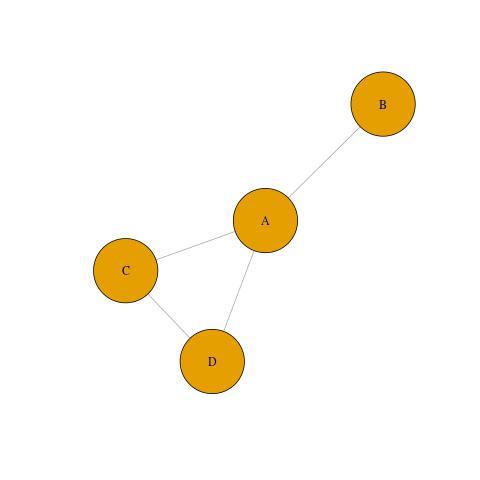

Por isso, uma importante propriedade de uma rede é o grau médio, que corresponde a média dos graus dos vértices. Essa métrica pode ser usada como indicador de coesão ou densidade de uma rede.

## Densidade

Formalmente, a densidade é uma medida relativa da quantidade de arestas que uma rede tem em relação com a máxima quantidade que ela poderia ter, considerando a sua quantidade de vértices.

No caso da rede anterior, por exemplo, o grau médio é de 2. Se todos os vértices possuíssem conexão com todos os demais (grau 3), o grau médio seria 3. Portanto, a rede possui um grau médio que corresponde a 66,7% ou 2/3 do grau médio máximo dada a quantidade de vértices.

Matematicamente, a densidade é definida como:

$D = {2E}/{N(N-1)}$

Em que E é a quantidade de arestas e N a quantidade de vértices.

## Coesão

A coesão ou conectividade dos vértices de uma rede é o número mínimo de vértices necessários para remover que reduziriam sua conectividade. Na rede de 4 vértices de exemplo, a coesão é igual a 1, pois basta remover o vértice A que a rede deixa de ser coesa.

## Comprimento médio do trajeto ou caminho

No contexto de redes, um trajeto ou caminho é uma rota que liga um vértice ao outro por meio das arestas. O comprimento de um trajeto, portanto, é o número de arestas que o trajeto contem. Normalmente, deseja-se saber qual o caminho mais curto entre dois dados vértices.

Assim, entende-se que o comprimento médio do trajeto é a média da distância entre todos os pares de vértices.

Os caminhos de uma rede também são importantes para definir o conceito a seguir:

## Diâmetro

Corresponde à máxima distância entre todos os pares de vértices de uma rede.

## Coeficiente de transitividade

Transitividade corresponde à capacidade que uma rede tem de formar triângulos entre os vértices. Se A, B e C são vértices de uma rede que apresenta perfeita transitividade, então se A está conectado, por meio de uma aresta, a B e B está conectado a C, então A está conectado com C. Esse triângulo recebe o nome de clique.

## Assortatividade

Em uma rede social, é comum que indivíduos que possuam coisas em comum sejam mais próximos entre si do que com aqueles sem muitos atributos semelhantes. Por exemplo, em uma rede social de universitários, é comum que pessoas interajam mais com outros que possuam o mesmo sexo, cor e classe social, entre outros. Toda escola tinha o grupinho dos nerds, das patricinhas, dos meninos que jogavam futebol, etc. Conceitualmente, esse fenômeno é conhecido como Homofilia, que afirma que um indivíduo tem mais chances de ser conectar com outros que possuam atributos semelhantes.

No contexto de Análise de Redes Sociais, Assortatividade é uma propriedade da rede que mede o seu grau de Homifilia. É numérico e definido de -1 a 1, onde, para um dado atributo (ex.: Sexo), um valor positivo indica que os vértices são mais conectados com outros que possuem o mesmo valor (ex.: Masculino com Masculino) do atributo, zero indica que o atributo não tem efeito nas conexões entre os vértices e um valor negativo indica que os vértices são mais próximos de vértices que possuam valores diferentes para o atributo (ex.: Masculino com Feminino).

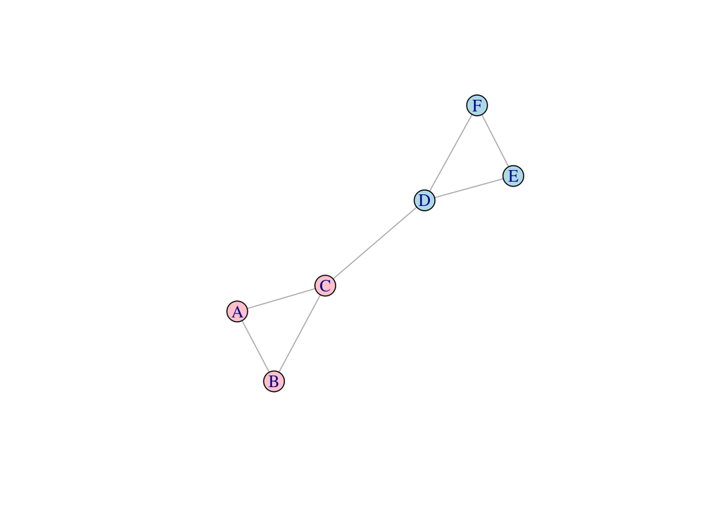

No grafo acima, a assortatividade é relativamente alta (0,71), visto que claramente existem grupos separados de mulheres e homens, sendo conectados apenas por uma aresta em comum (pessoas C e D).

## Reciprocidade

José é amigo de João, mas será que João é amigo de José?

A reciprocidade de uma rede nada mais é do que uma maneira de quantificar o porcentual de conexões mútuas entre os vértices. Por isso, deve-se ressaltar que essa propriedade só faz sentido para redes direcionadas. No gráfico abaixo, podem ser vistos dois grafos direcionados, um com reciprocidade (porem limitada) e outro sem reciprocidade.

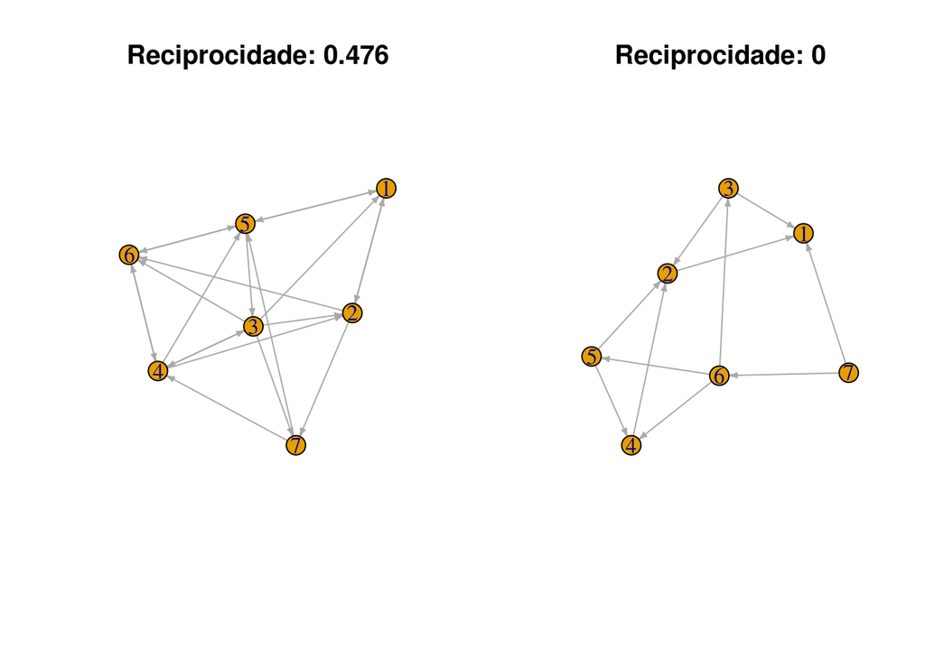

Na rede da esquerda, note como a conexão entre os vértices 1 e 2 é mútua, mas a conexão entre 1 e 3 não é.